# Analysis of Factors Contributing to Success in Formula 1

## Summary of Contents

1. Introduction
2. Data Files
3. Data Inspection and Cleaning
4. Analysis and Answers to Questions
5. Conclusions and Discussion
6. Future Analysis
7. References

## 1. Introduction

Formula 1 is often described as a data-driven sport, where milliseconds determine the difference between victory and defeat. While the drivers are the public face of the sport, success is a complex function of engineering reliability, race strategy, pit stops, qualifying performance, and driver skill.

This project analyzes historical data from the **Formula 1 World Championship (1950-2025)** to quantify these factors. By merging race results, telemetry, and constructor data, this report aims to answer the fundamental question: **"What actually leads to success in modern F1?"**

### Questions to be Answered:

1. Who are the most statistically dominant drivers in history?
2. How has the speed of pit stops evolved?
3. How critical is Qualifying?
4. Which top constructors in the Hybrid Era (2014-Present) have suffered the worst mechanical reliability?
5. Does the "Home Field Advantage" exist in F1?
6. What countries are the most successful in Formula 1?

These questions are interesting to me as I am a big Formula 1 fan and have been following the sport for a long time. I am curious to see how much of an impact each factor has on statistical success.

### 2. Data Files

These data files are all obtained from a dataset hosted on Kaggle.com that originally came from the F1 API:

https://www.kaggle.com/datasets/rohanrao/formula-1-world-championship-1950-2020/data

The dataset contains several files that are used in this analysis:

- `drivers.csv`: Drivers' personal information and statistics.
- `results.csv`: Race results and qualifying performance.
- `circuits.csv`: Circuit information and geographic location.
- `constructors.csv`: Constructor information and statistics.
- `status.csv`: Status messages for each race result.
- `pit_stops.csv`: Pit stop information and telemetry.
- `races.csv`: Race information and results.
- `driver_standings.csv`: Driver standings at the end of each race.

## 3. Data Inspection and Cleaning

### 3.1 - Importing required modules

```python
import pandas as pd
import matplotlib.pyplot as plt
import seaborn as sns
```

## 3.2 - `results.csv`

One of the main datasets we will be working with is `results.csv`. This contains the race results and qualifying performance for every driver. We however will want to be using `drivers.csv` to get the driver's names and nationalities as well. Hence we will be creating a dataframe that merges the two so we can easily reference drivers names and their results in a single table.

```python
# Merging the two datasets
drivers_df = pd.read_csv('data/drivers.csv')
print('-- drivers.csv --')
print(drivers_df.head())
print("\n")

results_df = pd.read_csv('data/results.csv')
print('-- results.csv --')
print(results_df.head())
print("\n")
merged_df = pd.merge(results_df, drivers_df, on='driverId', how='left')

# Checking the shape and info of the merged dataframe
print('-- Merged Data --')
print(merged_df.head())
print("\n")
print('-- Data Shape --')
print(merged_df.shape)
print("\n")
print('-- Data Info --')
print(merged_df.info())
print("\n")
print('-- Missing Values --')
print(merged_df.isnull().sum())
print("\n")
print('-- Duplicate Rows --')
print(f"Duplicate rows: {merged_df.duplicated().sum()}")
```

[output not shown]

[output cut: 89 more lines]

```
fastestLapSpeed    0
statusId           0
driverRef          0
number_y           0
code               0
forename           0
surname            0
dob                0
nationality        0
url                0
dtype: int64


-- Duplicate Rows --
Duplicate rows: 0
```

## Corrections

Overall this data looks pretty good. There are no duplicate rows and no missing values. There is one main correction that we will want to make regarding the driver's names. As seen in the `forename` and `surname` columns, some drivers went on to have children who also competed in Formula 1. This means that their names are not unique and any time we use the `surname` column we will be getting data for whoever shares that same surname. We will need to merge these two columns to create a unique identifier for each driver.

```python
merged_df['full_name'] = merged_df['forename'] + ' ' + merged_df['surname']
```

## 3.3 - `pitstops.csv`

Another table we will want to use is one containing data on pit stops from every race. We will want to merge this dataframe with `races.csv` to specifically get the year of the race the pit stop was made.

```python
pit_stops_df = pd.read_csv('data/pit_stops.csv')
races_df = pd.read_csv('data/races.csv')

print('-- pit_stops.csv --')
print(pit_stops_df.head())
print("\n")
print('-- races.csv --')
print(races_df.head())
print("\n")

stops_with_year = pd.merge(pit_stops_df, races_df[['raceId', 'year', 'name']], on='raceId', how='left')
print('-- Stops with Year --')
print(stops_with_year.head())
print("\n")

# Checking the shape and info of the merged dataframe
print('-- Merged Data --')
print(stops_with_year.head())
print("\n")
print('-- Data Shape --')
print(stops_with_year.shape)
print("\n")
print('-- Data Info --')
print(stops_with_year.info())
print("\n")
print('-- Missing Values --')
print(stops_with_year.isnull().sum())
print("\n")
print('-- Duplicate Rows --')
print(f"Duplicate rows: {stops_with_year.duplicated().sum()}")
```

```
-- pit_stops.csv --
   raceId  driverId  stop  lap      time duration  milliseconds
0     841       153     1    1  17:05:23   26.898         26898
1     841        30     1    1  17:05:52   25.021         25021
2     841        17     1   11  17:20:48   23.426         23426
3     841         4     1   12  17:22:34   23.251         23251
4     841        13     1   13  17:24:10   23.842         23842


-- races.csv --
   raceId  year  round  circuitId                   name        date  \
0       1  2009      1          1  Australian Grand Prix  2009-03-29
1       2  2009      2          2   Malaysian Grand Prix  2009-04-05
2       3  2009      3         17     Chinese Grand Prix  2009-04-19
3       4  2009      4          3     Bahrain Grand Prix  2009-04-26
4       5  2009      5          4     Spanish Grand Prix  2009-05-10

       time                                                url fp1_date  \
0  06:00:00  http://en.wikipedia.org/wiki/2009_Australian_G...       \N
1  09:00:00  http://en.wikipedia.org/wiki/2009_Malaysian_Gr...       \N
2  07:00:00  http://en.wikipedia.org/wiki/2009_Chinese_Gran...       \N
3  12:00:00  http://en.wikipedia.org/wiki/2009_Bahrain_Gran...       \N
4  12:00:00  http://en.wikipedia.org/wiki/2009_Spanish_Gran...       \N

  fp1_time fp2_date fp2_time fp3_date fp3_time quali_date quali_time  \
0       \N       \N       \N       \N       \N         \N         \N
1       \N       \N       \N       \N       \N         \N         \N
2       \N       \N       \N       \N       \N         \N         \N
3       \N       \N       \N       \N       \N         \N         \N
4       \N       \N       \N       \N       \N         \N         \N

  sprint_date sprint_time
0          \N          \N
1          \N          \N
2          \N          \N
3          \N          \N
4          \N          \N


-- Stops with Year --
```

[output cut: 55 more lines]

```
-- Missing Values --
raceId          0
driverId        0
stop            0
lap             0
time            0
duration        0
milliseconds    0
year            0
name            0
dtype: int64


-- Duplicate Rows --
Duplicate rows: 0
```

## Corrections

Again, this data looks clean with no missing values or duplicate rows. We will now convert the duration from milliseconds to seconds to make for easier reading. We will also here be filtering out pit stops with a time larger than 50 seconds, as these are usually red flag events or complete repair-jobs. We want timing data of JUST race strategy pit-stops

```python
# Convert milliseconds to seconds
stops_with_year['seconds'] = stops_with_year['milliseconds'] / 1000

# Filter out stops longer than 50 seconds
clean_stops = stops_with_year[stops_with_year['seconds'] < 50]
```

## 4. Analysis and Answers to Questions

### 4.1: Who are the most dominant drivers in F1 history?

To establish a baseline, we first identify the drivers with the highest total career wins. We already merged the `drivers` and `results` tables, and the `full_name` column was also created to ensure uniqueness. A simple bar graph will show us the most dominant drivers.

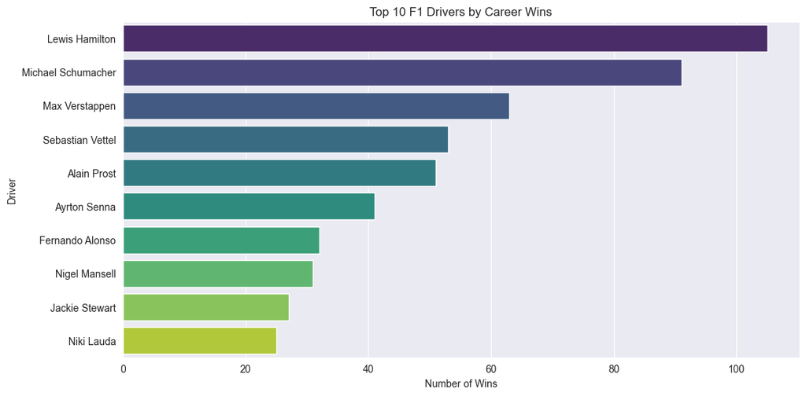

```python
# --- Question 1: Who is the most dominant driver? ---

# Filter for only Race Winners
winners = merged_df[merged_df['position'] == '1']

# Count how many times a driver appears and get the top 10
top_winners = winners['full_name'].value_counts().head(10)

# Create the chart
plt.figure(figsize=(12, 6)) # Width, Height
sns.barplot(
    x=top_winners.values,
    y=top_winners.index,
    hue=top_winners.index,
    legend=False,
    palette='viridis'
)

# Add Labels
plt.title('Top 10 F1 Drivers by Career Wins')
plt.xlabel('Number of Wins')
plt.ylabel('Driver')

# Show
plt.show()
```

### 4.2: How has the speed of pit stops evolved over time?

We analyzed `pit_stops.csv` (available from 2011 onwards). We calculated the **median** time spent in the pit lane per year to filter out long repair stops. A simple line graph will show us how pit stop times have evolved over time.

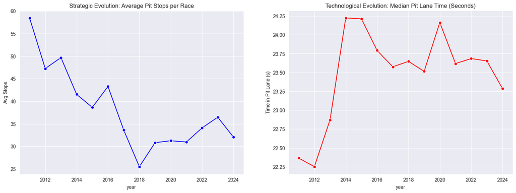

```python
# --- Question 2: Pit Stop Trends ---

# Calculate the stats by Year
yearly_stats = clean_stops.groupby('year')['seconds'].agg(['count', 'median']).reset_index()

# We need to normalize 'count' by number of races that year,
# otherwise years with 22 races look "busier" than years with 16.
races_per_year = races_df.groupby('year')['raceId'].count()
yearly_stats['races_count'] = yearly_stats['year'].map(races_per_year)
yearly_stats['avg_stops_per_race'] = yearly_stats['count'] / yearly_stats['races_count']

# Creating two Subplots Side-by-Side
fig, axes = plt.subplots(1, 2, figsize=(18, 6))

# Plot 1: Frequency
sns.lineplot(ax=axes[0], x=yearly_stats['year'], y=yearly_stats['avg_stops_per_race'], marker='o', color='blue')
axes[0].set_title('Strategic Evolution: Average Pit Stops per Race')
axes[0].set_ylabel('Avg Stops')
axes[0].grid(True)

# Plot 2: Duration
sns.lineplot(ax=axes[1], x=yearly_stats['year'], y=yearly_stats['median'], marker='o', color='red')
axes[1].set_title('Technological Evolution: Median Pit Lane Time (Seconds)')
axes[1].set_ylabel('Time in Pit Lane (s)')
axes[1].grid(True)

# Show
plt.show()
```

**Observation:**

The data reveals a distinct step in pit stop time in 2014. This is due to a sporting regulation change in 2014 that reduced the pit lane speed limit from 100km/h to 80km/h. (https://www.autoweek.com/racing/formula-1/a1924511/fia-mandate-2014-formula-one-pit-safety-rules-immediately/). There does seem to be a small trend continuing downwards since then, indicating that Formula 1 teams do tend to optimize every aspect of the sport. This is also evident in the graph showing there has been a sharp downward trend of the number of pit stops taken every race.

### 4.3: How critical is Qualifying?

We tested the win probability for every starting grid position. We counted the frequency of wins from Grid position P1, P2, P3, etc., and calculated the percentage of total races won from Pole Position. A simple bar graph will show us how critical this is.

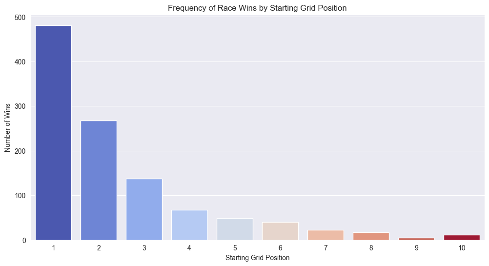

```
Total Races Analyzed: 1128
Wins from Pole Position: 481
Percentage of wins from Pole: 42.64%
```

```python
# --- Question 3: The Importance of Qualifying ---

# Filter for winners
winners = merged_df[merged_df['positionOrder'] == 1]

# Count how many wins came from each Grid Position
grid_wins = winners['grid'].value_counts().sort_index()

# Getting data from the top 10 grid positions
top_grid_wins = grid_wins.head(10)

# Visualize
plt.figure(figsize=(12, 6))
sns.barplot(
    x=top_grid_wins.index,
    y=top_grid_wins.values,
    hue=top_grid_wins.index,
    palette='coolwarm',
    legend=False
)

plt.title('Frequency of Race Wins by Starting Grid Position')
plt.xlabel('Starting Grid Position')
plt.ylabel('Number of Wins')
plt.show()

# Calculating the Percentage of Wins from Pole Position
total_races = len(winners)
wins_from_pole = grid_wins.get(1, 0)
pole_win_percentage = (wins_from_pole / total_races) * 100

print(f"Total Races Analyzed: {total_races}")
print(f"Wins from Pole Position: {wins_from_pole}")
print(f"Percentage of wins from Pole: {pole_win_percentage:.2f}%")
```

**Observation:**

There is a steep staircase shape to the data. Approximately 43% of all races in history have been won from Pole Position, and there is a sharp drop-off after P3, indicating that despite the length of the race (300km), the starting position is a significant predictor of victory. Again placing importance on driver skill. There are also some outliers, such as P10, but this can be explained by chaotic races such as those involving wet weather.

### 4.4: Which top constructor has the worst reliability in the Hybrid Era?

We analyzed the "Hybrid Era" (2014–Present) to see which teams suffered the most mechanical failures. We merged `results` with `status` and `constructors`. We filter for status messages containing "Engine," "Gearbox", or "Clutch", excluding accidents (which are driver error) to place the importance of a team's reliability. A simple bar graph will show us which teams had the worst reliability.

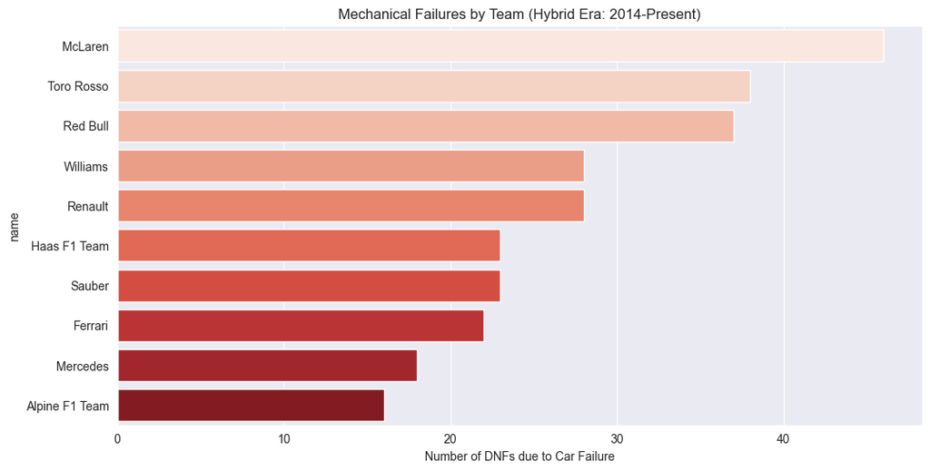

```python
# --- Question 4: Manufacturer Reliability ---

# Load the necessary files
results_df = pd.read_csv('data/results.csv')
races_df = pd.read_csv('data/races.csv')
status_df = pd.read_csv('data/status.csv')
constructors_df = pd.read_csv('data/constructors.csv')

# Merge 1: Results + Races (to get the Year)
df = pd.merge(results_df, races_df[['raceId', 'year']], on='raceId', how='left')

# Merge 2: + Status (to know why they stopped)
df = pd.merge(df, status_df, on='statusId', how='left')

# Merge 3: + Constructors (to get the Team Name)
df = pd.merge(df, constructors_df[['constructorId', 'name']], on='constructorId', how='left')

# Filter for Hybrid Era (2014 onwards)
hybrid_era = df[df['year'] >= 2014]

# Define "Mechanical Failure"
# We exclude accidents and "Finished" statuses.
# We look for keywords that indicate the CAR broke.
mechanical_keywords = [
    'Engine', 'Gearbox', 'Transmission', 'Clutch', 'Hydraulics',
    'Electrical', 'Power Unit', 'Brakes', 'Suspension', 'Turbo',
    'Exhaust', 'Overheating', 'Mechanical', 'Battery', 'Radiator',
    'Driveshaft', 'Hydraulics', 'Differential', 'Fuel Pressure',
    'Water Pressure', 'Throttle', 'Steering', 'Technical', 'Heat shield fire',
    'Water leak', 'Fuel pump', 'Track rod', 'Oil pressure', 'Pneumatics',
    'Wheel bearing', 'Fuel system', 'Drivetrain', 'Power loss', 'Fuel',
    'Ignition', 'Battery', 'Chassis', 'Crankshaft', 'Alternator', 'Oil pump',
    'Injection', 'Spark plugs', 'Fuel pipe', 'Oil pipe', 'Water pipe',
    'Power unit', 'ERS', 'Cooling system'
]

# Create a filter pattern (e.g., "Engine|Gearbox|Clutch")
pattern = '|'.join(mechanical_keywords)

# Filter for rows where the status string contains one of our keywords
mechanical_failures = hybrid_era[hybrid_era['status'].str.contains(pattern, case=False, na=False)]

# Analyze: Count failures by Team
failure_counts = mechanical_failures['name'].value_counts().head(10)

# Visualize
plt.figure(figsize=(12, 6))
sns.barplot(
    x=failure_counts.values,
    y=failure_counts.index,
    hue=failure_counts.index,
    palette='Reds', # Red palette fits the "danger/failure" theme
    legend=False
)

# Show
plt.title('Mechanical Failures by Team (Hybrid Era: 2014-Present)')
plt.xlabel('Number of DNFs due to Car Failure')
plt.show()
```

**Observation:**

The data highlights the struggle of manufacturers like McLaren (during the troubled Honda partnership) and Renault. In contrast, Mercedes shows a lower frequency of mechanical failures, suggesting their dominance in this era was built much on bulletproof reliability. Note that the Renault F1 team became the Alpine F1 team in 2021, so the Renault operation as a whole can be considered to have very poor reliability. Including stats from their customer teams such as Red-bull and McLaren, although those teams have since moved on to different engine partners.

### 4.5: Does "Home Field Advantage" exist in F1?

Unlike other sports, F1 drivers do not train on their home track daily. However, the psychological boost of a home crowd is often discussed. We performed a 4-way merge (Drivers -> Results -> Races -> Circuits). We mapped demonyms (e.g., 'Australian') to countries (e.g., 'Australia') of the main F1 driver + track combinations and compared average finishing positions. We can use a bar graph to visualize the results.

```
Average Finish Position (Away): 12.66
Average Finish Position (Home): 14.26
```

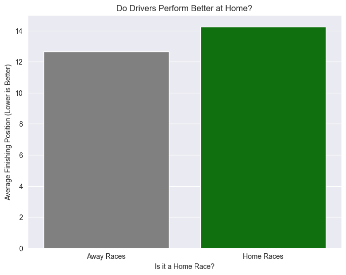

```python
# --- Question 5: Home Field Advantage ---

# Load the necessary files
drivers_df = pd.read_csv('data/drivers.csv')
races_df = pd.read_csv('data/races.csv')
results_df = pd.read_csv('data/results.csv')
circuits_df = pd.read_csv('data/circuits.csv')

# Merge Data
# Merge A: Results + Drivers (to get Driver Nationality)
df = pd.merge(results_df, drivers_df[['driverId', 'nationality', 'forename', 'surname']], on='driverId', how='left')

# Merge B: Races + Circuits (to get the Circuit Country)
races_with_country = pd.merge(races_df, circuits_df[['circuitId', 'country']], on='circuitId', how='left')

# Merge C: Combine A + B (Match Race ID)
full_df = pd.merge(df, races_with_country[['raceId', 'name', 'country']], on='raceId', how='left')

# Map Demonym to Country Name
nationality_map = {
    'British': 'UK',
    'German': 'Germany',
    'Spanish': 'Spain',
    'French': 'France',
    'Italian': 'Italy',
    'Brazilian': 'Brazil',
    'Australian': 'Australia',
    'Austrian': 'Austria',
    'American': 'USA',
    'Dutch': 'Netherlands',
    'Mexican': 'Mexico',
    'Canadian': 'Canada',
    'Japanese': 'Japan',
    'Belgian': 'Belgium',
    'Monegasque': 'Monaco'
}

# Apply map
full_df['driver_country'] = full_df['nationality'].map(nationality_map)

# Drop rows where we couldn't map the nationality
df_clean = full_df.dropna(subset=['driver_country']).copy()

# Create the Boolean Logic
df_clean['is_home_race'] = df_clean['driver_country'] == df_clean['country']

home_stats = df_clean.groupby('is_home_race')['positionOrder'].mean()

print(f"Average Finish Position (Away): {home_stats[False]:.2f}")
print(f"Average Finish Position (Home): {home_stats[True]:.2f}")

# Visualize
plt.figure(figsize=(8, 6))
sns.barplot(
    x=home_stats.index,
    y=home_stats.values,
    hue=home_stats.index,
    legend=False,
    palette=['grey', 'green']
)

plt.title('Do Drivers Perform Better at Home?')
plt.xlabel('Is it a Home Race?')
plt.ylabel('Average Finishing Position (Lower is Better)')
plt.xticks([0, 1], ['Away Races', 'Home Races'])
plt.ylim(0, 15)
plt.show()
```

**Observation:**

The results show a small difference between Home and Away performance. While it could be considered negligible, it could also suggest that the added pressures of racing in front of a home crowd could have negative psychological consequences for a driver. As seen this year in Italy as Kimi Antonelli admitted increased pressure and media obligations lead to a disappointing race weekend. (https://www.formula1.com/en/latest/article/antonelli-admits-to-not-managing-intense-home-pressure-the-best-during.2XaHurmRMWBpnIxgeSlfpu)

### 4.6 Which country is the most successful in F1?

Finally, we want to see which country produces the most champions. To do this we will use the `driver_standings.csv` data file to get the Champion of that year (Driver with the most points at the end of the last race) and get their nationality. We will use a pie chart to visualize the results.

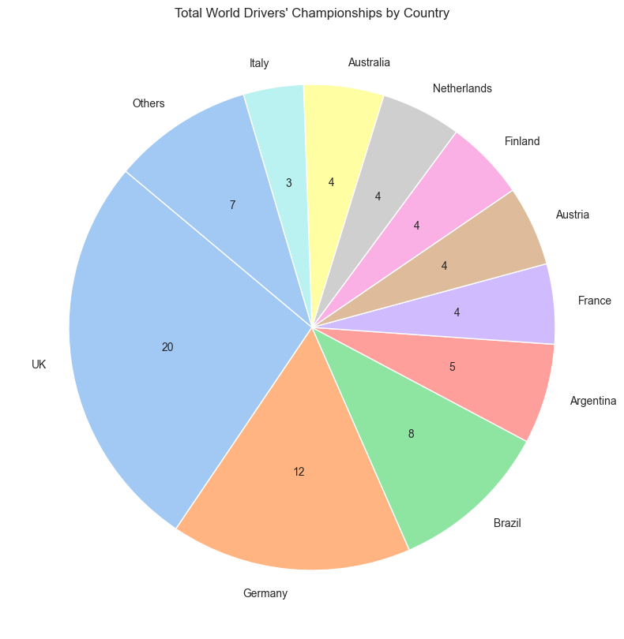

```python
# --- Question 6: Most Successful Countries ---

# Load the necessary files
standings_df = pd.read_csv('data/driver_standings.csv')
races_df = pd.read_csv('data/races.csv')
drivers_df = pd.read_csv('data/drivers.csv')

# Identify the Final Race of each Year
# We group by Year and find the max 'round' (the last race)
final_races = races_df.loc[races_df.groupby('year')['round'].idxmax()]

# Merge Standings with these Final Races
# This leaves us with only the standings after the final race of every season
season_end_standings = pd.merge(standings_df, final_races[['raceId', 'year']], on='raceId')

# Filter for the Champion (Position 1)
champions = season_end_standings[season_end_standings['position'] == 1]

# Merge with Drivers to get Nationality
champions_with_info = pd.merge(champions, drivers_df[['driverId', 'nationality']], on='driverId')

# Apply the Nationality Map from the previous question
nationality_map = {
    'British': 'UK',
    'German': 'Germany',
    'Spanish': 'Spain',
    'French': 'France',
    'Italian': 'Italy',
    'Brazilian': 'Brazil',
    'Australian': 'Australia',
    'Austrian': 'Austria',
    'American': 'USA',
    'Dutch': 'Netherlands',
    'Mexican': 'Mexico',
    'Canadian': 'Canada',
    'Japanese': 'Japan',
    'Belgian': 'Belgium',
    'Monegasque': 'Monaco',
    'Finnish': 'Finland',  # Added typical Champions nationalities
    'Argentine': 'Argentina',
    'New Zealander': 'New Zealand',
    'South African': 'South Africa'
}
champions_with_info['country'] = champions_with_info['nationality'].map(nationality_map).fillna(champions_with_info['nationality'])

# Count Titles by Country
country_counts = champions_with_info['country'].value_counts()

# Create the Pie Chart
plt.figure(figsize=(10, 10))

# Grabbing the top 10 countries to keep the chart readable,
# adding any countries not in the top 10 as "Others"
top_countries = country_counts.head(10)
others_count = country_counts.iloc[10:].sum()

if others_count > 0:
    top_countries['Others'] = others_count

# Custom function to show the number of champions from each country instead of percentages
def make_autopct(values):
    def my_autopct(pct):
        total = sum(values)
        val = int(round(pct*total/100.0))
        return '{v:d}'.format(v=val) # Returns the number
    return my_autopct

# Visualize
plt.pie(
    top_countries.values,
    labels=top_countries.index,
    autopct=make_autopct(top_countries.values),
    startangle=140,
    colors=sns.color_palette('pastel')
)

plt.title('Total World Drivers\' Championships by Country')
plt.show()
```

**Observation:**

What we see is a clear dominance of European countries in F1 championship history, with the UK and Germany leading the pack. This suggests that F1 is a sport deeply rooted in European culture and engineering excellence. Given that Formula 1 originated in the UK in 1950, it's no surprise that these countries have produced many of the sport's most successful drivers and teams.

## 5. Conclusions and Discussions

The primary objective of this project was to deconstruct the factors contributing to success in Formula 1. By analyzing over 70 years of race data, we have determined that victory is rarely a result of chance, but rather a predictable outcome of driver skill and team performance working in harmony. With an emphasis on constant optimization of both these factors, a Formula 1 team can achieve statistical success.

The analysis of qualifying data (Q3) revealed a strong correlation between starting grid position and victory probability. This correlation is not surprising, as the more a driver is ahead of the pack, the more likely they are to win. While this does signify the importance of having a skilled driver on the team, it also highlights the importance of team dominance. Pole position in qualifying has a 43% win conversion rate. Any constructor would have to work on giving its drivers a mechanically superior car to give them a higher chance of qualifying 1st. This is further illustrated by the dominance of specific drivers (Q1), whose high win counts correlate with cars that were statistically dominant in one-lap pace.

Finally, the analysis of the home field advantage (Q5) revealed that the sport is not always dominated by pure numbers and engineering. The results of Q5 show that while small, there is a quantitative difference between driver's performance at home and away from home crowds. While this could be considered negligible, it could also suggest that the added pressures of racing in front of a home crowd could have negative psychological consequences for a driver, indicating there is always a human element to racing. This could also be inferred from the fact that the most successful drivers come from countries with Formula 1 ingrained into their culture such as the UK and Germany (Q6).

## 6. Future Analysis

To deepen this study, future work could incorporate:

- **Mechanical Failures over time:** Analyzing the trend of mechanical failures, or lack thereof, over time as teams improve..
- **Weather Data:** Correlating rain probability with "surprise" winners (wins from outside the top 10).
- **Budget Cap Analysis:** Comparing team dominance before and after the 2021 Cost Cap implementation.
- **Lap-by-Lap Telemetry:** Analyzing tire degradation curves to see if certain drivers (like Lewis Hamilton) strictly have better tire management than their teammates.

## 7. References

- **Data Source:** Ergast F1 Database (Kaggle / API).
- **Python Libraries:** Pandas, Matplotlib, Seaborn.